# Homework Assignment 1

Author: Jiyun Bak

Assigned: Oct 24, 2020, Due Sun Nov 01, 2020 11:59PM

# Basic Exploration

```r
nyc = read.csv("nycflights.csv")

# Delete first column
nyc$X = NULL

# Factorizing variables
nyc$origin = as.factor(nyc$origin)
nyc$tailnum = as.factor(nyc$tailnum)
nyc$month = as.factor(nyc$month)
nyc$dest = as.factor(nyc$dest)
nyc$carrier = as.factor(nyc$carrier)
nyc$flight = as.factor(nyc$flight)
```

### How many airlines are there?

```r
length(levels(nyc$carrier))
```

```
## [1] 16
```

### How many flights there were by the airline with code OO?

```r
nyc00 = nrow(nyc[nyc$carrier == "OO",])
```

[output not shown]

### How long is the shortest flight out of any NYC airport?

```r
min(nyc$air_time, na.rm=TRUE)
```

```
## [1] 20
```

### How many flights where there by United Airlines (code: UA) on Jan 12th 2013?

```r
UA <- nyc[nyc$carrier == "UA" & nyc$year==2013 & nyc$month==1 & nyc$day==12, ]
nrow(UA)
```

```
## [1] 112
```

# Arrival Delay

### What was the average arrival delay for all airports and all airlines combined in Jan 2013?

```r
janflight = nyc[nyc$month == "1",]
round(mean(janflight$arr_delay, na.rm=TRUE), 2)
```

```
## [1] 6.13
```

### What was the median arrival delay for all airports and all airlines combined in Jan 2013?

```r
round(median(janflight$arr_delay, na.rm=TRUE), 2)
```

```
## [1] -3
```

# Airline Performance

### Calculate average arrival delays by airline

```r
delay = tapply(nyc$arr_delay, nyc$carrier, mean, na.rm=TRUE)
```

### Draw a Bar Plot of Average Arrival Delays for all the Airlines

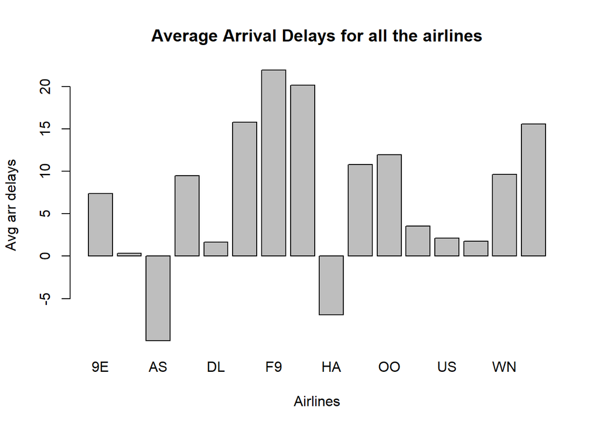

```r
barplot(delay, main="Average Arrival Delays for all the airlines",
        xlab = "Airlines", ylab = "Avg arr delays")
```

### Which airline has the highest average arrival delay? Which airline has the smallest average arrival delay? Are there airlines that actually have negative average delay?

```r
# Highest average arrival delay
high <- names(delay[delay==max(delay)])

# Smallest average arrival delay
small <- names(delay[delay==min(delay)])

# Negative average delay
neg <- names(delay[delay[ ] < 0 ])
```

Highest average arrival delay airline : F9

Smallest average arrival delay airline : AS

Negative average arrival delay airline : AS, HA

# Air Gain

```r
nyc$airgain <- nyc$dep_delay - nyc$arr_delay
```

### a) Explore airgain data

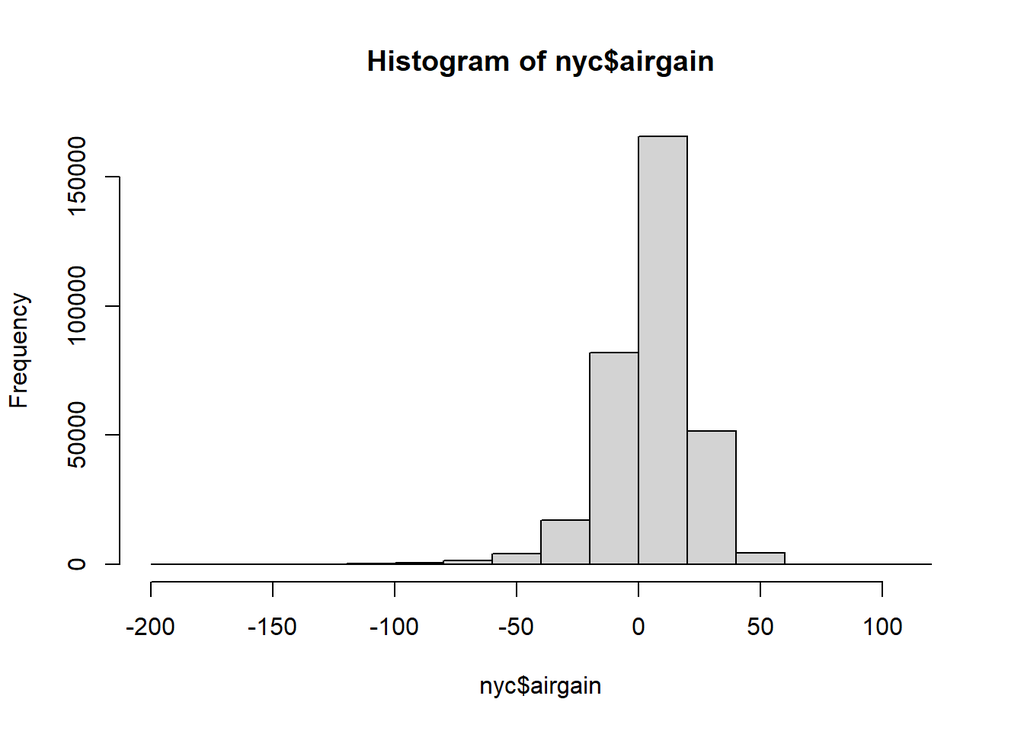

```r
hist(nyc$airgain)
```

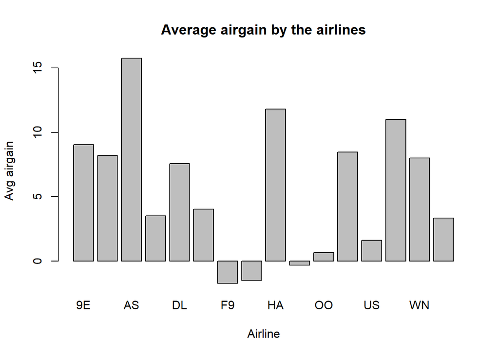

```r
bycarrier <- tapply(nyc$airgain, nyc$carrier, mean, na.rm=TRUE)
barplot(bycarrier, main="Average airgain by the airlines",
        xlab = "Airline", ylab="Avg airgain")
```

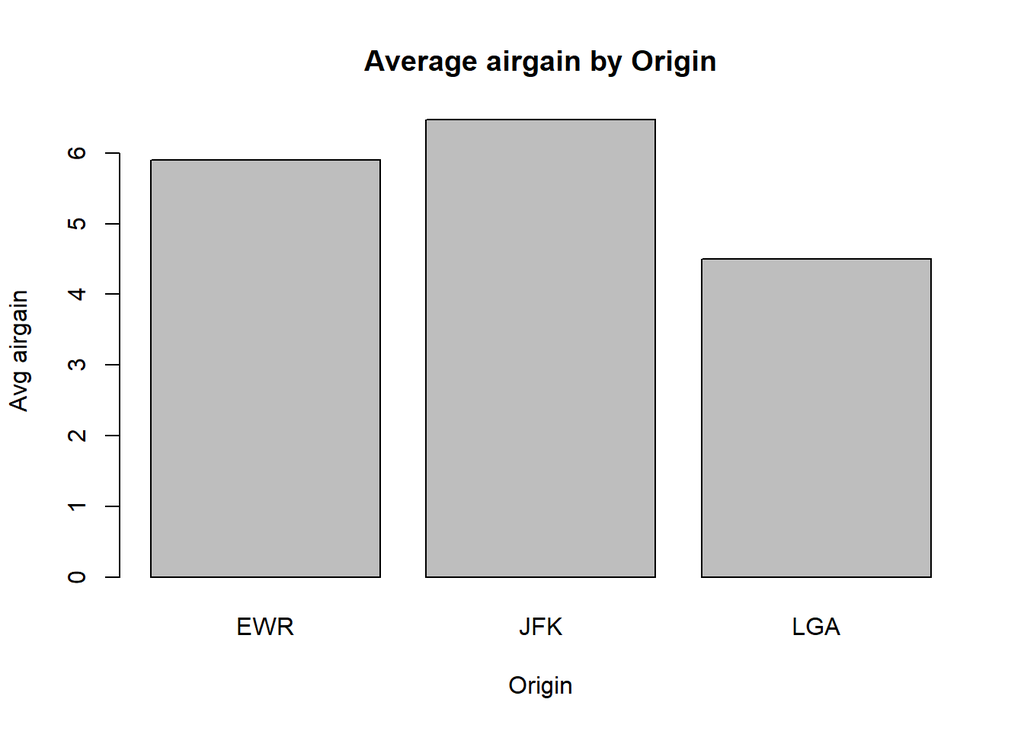

```r
byorigin <- tapply(nyc$airgain, nyc$origin, mean, na.rm=TRUE)
barplot(byorigin, main="Average airgain by Origin",
        xlab = "Origin", ylab="Avg airgain")
```

```r
aggregate(airgain~origin+carrier, data=nyc, mean)
```

```
##    origin carrier    airgain
## 1     EWR      9E  4.0410729
## 2     JFK      9E  9.8593363
## 3     LGA      9E  6.9410767
## 4     EWR      AA  9.0077312
## 5     JFK      AA  8.1949265
## 6     LGA      AA  8.0336359
## 7     EWR      AS 15.7616361
## 8     EWR      B6  3.6206737
## 9     JFK      B6  3.8175251
## 10    LGA      B6  1.2172221
## 11    EWR      DL  3.2754366
## 12    JFK      DL 10.6680286
## 13    LGA      DL  5.6059025
## 14    EWR      EV  3.0269028
```

[output cut: 21 more lines]

### b) Answer the questions -

### i) do airlines actually gain any time when in air on average?

```r
carair <- aggregate(airgain~carrier, data=nyc, mean)
carair[carair$airgain < 0, ]
```

```
##    carrier    airgain
## 7       F9 -1.7195301
## 8       FL -1.5099213
## 10      MQ -0.3293526
```

### ii) Calculate average airgain for different airlines - which airlines do a better job, which do a worse job?

```r
carair
```

```
##    carrier    airgain
## 1       9E  9.0599052
## 2       AA  8.2048393
## 3       AS 15.7616361
## 4       B6  3.5095746
## 5       DL  7.5796089
## 6       EV  4.0424982
## 7       F9 -1.7195301
## 8       FL -1.5099213
## 9       HA 11.8157895
## 10      MQ -0.3293526
## 11      OO  0.6551724
## 12      UA  8.4588972
## 13      US  1.6150976
## 14      VX 10.9921814
## 15      WN  8.0125374
## 16      YV  3.3419118
```

```r
#Max
carair$carrier[which.max(carair$airgain)]
```

```
## [1] AS
## Levels: 9E AA AS B6 DL EV F9 FL HA MQ OO UA US VX WN YV
```

```r
#Min
carair$carrier[which.min(carair$airgain)]
```

```
## [1] F9
## Levels: 9E AA AS B6 DL EV F9 FL HA MQ OO UA US VX WN YV
```

# Merging Data Frames

```r
library(data.table)
plane <- read.csv("planes.csv")

plane$X = NULL
plane$tailnum <- as.factor(plane$tailnum)
plane$year <- as.factor(plane$year)
plane$manufacturer <- as.factor(plane$manufacturer)
plane$model <- as.factor(plane$model)
plane$engine <- as.factor(plane$engine)
plane <- as.data.frame(plane)
```

### b) Merge the flights data and the planes data using the merge command.

```r
m_data <- merge(nyc, plane, by = "tailnum")

View(m_data)
```

### c-1. Which manufacturers do make the largest&smallest average airgain plane?

```r
byman <- tapply(m_data$airgain, m_data$manufacturer, mean, na.rm=TRUE)
# Highest average arrival delay
max_man <- names(byman[byman==max(byman)])
min_man <- names(byman[byman==min(byman)])
```

The largest average airgain manufacturer: AMERICAN AIRCRAFT INC

The smallest average airgain manufacturer: HURLEY JAMES LARRY

### c-2. Which models do fly the average longest & shortest distance?

```r
dist_model <- tapply(m_data$distance, m_data$model, mean, na.rm=TRUE)
longdist_m <- names(dist_model[dist_model==max(dist_model)])
shortdist_m <- names(dist_model[dist_model==min(dist_model)])
longdist <- dist_model[dist_model==max(dist_model)]
shortdist <- dist_model[dist_model==min(dist_model)]
longdist
```

```
## A330-243
##     4983
```

```r
shortdist
```

```
## CL-600-2B19
##    333.3568
```

A330-243 flies the longest distance as of 4983, and CL-600-2B19 flies the shortest distance as of 333.3568002.

### c-3. What are the top 5 most frequent destination airports flying from JFK airport?

```r
m_data$cnt = 1
ori_dest <-as.data.frame(aggregate(cnt~origin+dest, data=m_data, sum))
jfk <- ori_dest[ori_dest$origin=="JFK", ]
jfk <- jfk[order(-jfk$cnt),]
jfk[1:5, 2:3]
```

```
##     dest   cnt
## 106  LAX 11082
## 195  SFO  7751
## 113  MCO  4735
## 20   BOS  4393
## 75   FLL  4003
```

### c-4. Which month does have the largest number of flights?

```r
mon<-tapply(m_data$cnt, m_data$month, sum, na.rm=TRUE)
max_month <- names(mon[mon==max(mon)])
max_month
```

```
## [1] "8"
```

### c-5. Is there any relationship between the airgain and the number of engines?

```r
tapply(m_data$airgain, m_data$engines, mean, na.rm=TRUE)
```

```
##           1           2           3           4
##  4.42466460  6.05628315 10.00000000  0.06015038
```

It seems that there is a linear relationship between the airgain and the number of engines until the plane has 4 engines. As the number of engines increases, the average airgain also increases.